# HW #3: Monster Lab Meeting

Gaea Daniel

February 15, 2017

```r
White_wines <- read.csv("White_wines.csv")
#To load necessary packages
library(lattice)
library(latticeExtra)
library(Rcmdr)
library(RcmdrMisc)
library(RColorBrewer)
library(datasets)
library(car)
#Import "White_wines.csv" data from Files
```

You are now the data slave to the principal investigator Dr. Vinca Monster. Dr. M is in the Grape Program at State U, and you are just a poor graduate student trying to get your degree. Dr. M is interested in wine preferences and the influences of physico-chemical properties on preferences. Her laboratory has gathered an extensive dataset on Portugese white varietals.

You will find the white_wines.csv file and its description in my github repo (https://github.com/vhertzb/Regression-1)[https://github.com/vhertzb/Regression-1].

Please use the techniques you have learned in the last two classes, specifically exploratory data analysis and linear regression, to determine association of the wine properties on preference.

Prepare a report for presentation at the next Monster lab meeting about this dataset.

Rubric:

Exploration (summary statistics (the m’s), univariate graphs, multivariate graphs)

```r
#To get the summary statistics for all the variables
summary(White_wines)
```

```
##  fixed.acidity    volatile.acidity  citric.acid     residual.sugar
##  Min.   : 3.800   Min.   :0.0800   Min.   :0.0000   Min.   : 0.600
##  1st Qu.: 6.300   1st Qu.:0.2100   1st Qu.:0.2700   1st Qu.: 1.700
##  Median : 6.800   Median :0.2600   Median :0.3200   Median : 5.200
##  Mean   : 6.855   Mean   :0.2782   Mean   :0.3342   Mean   : 6.391
##  3rd Qu.: 7.300   3rd Qu.:0.3200   3rd Qu.:0.3900   3rd Qu.: 9.900
##  Max.   :14.200   Max.   :1.1000   Max.   :1.6600   Max.   :65.800
##    chlorides       free.sulfur.dioxide total.sulfur.dioxide
##  Min.   :0.00900   Min.   :  2.00      Min.   :  9.0
##  1st Qu.:0.03600   1st Qu.: 23.00      1st Qu.:108.0
##  Median :0.04300   Median : 34.00      Median :134.0
##  Mean   :0.04577   Mean   : 35.31      Mean   :138.4
##  3rd Qu.:0.05000   3rd Qu.: 46.00      3rd Qu.:167.0
##  Max.   :0.34600   Max.   :289.00      Max.   :440.0
##     density             pH          sulphates         alcohol
##  Min.   :0.9871   Min.   :2.720   Min.   :0.2200   Min.   : 8.00
##  1st Qu.:0.9917   1st Qu.:3.090   1st Qu.:0.4100   1st Qu.: 9.50
##  Median :0.9937   Median :3.180   Median :0.4700   Median :10.40
##  Mean   :0.9940   Mean   :3.188   Mean   :0.4898   Mean   :10.51
##  3rd Qu.:0.9961   3rd Qu.:3.280   3rd Qu.:0.5500   3rd Qu.:11.40
##  Max.   :1.0390   Max.   :3.820   Max.   :1.0800   Max.   :14.20
##     quality
##  Min.   :3.000
##  1st Qu.:5.000
##  Median :6.000
##  Mean   :5.878
##  3rd Qu.:6.000
##  Max.   :9.000
```

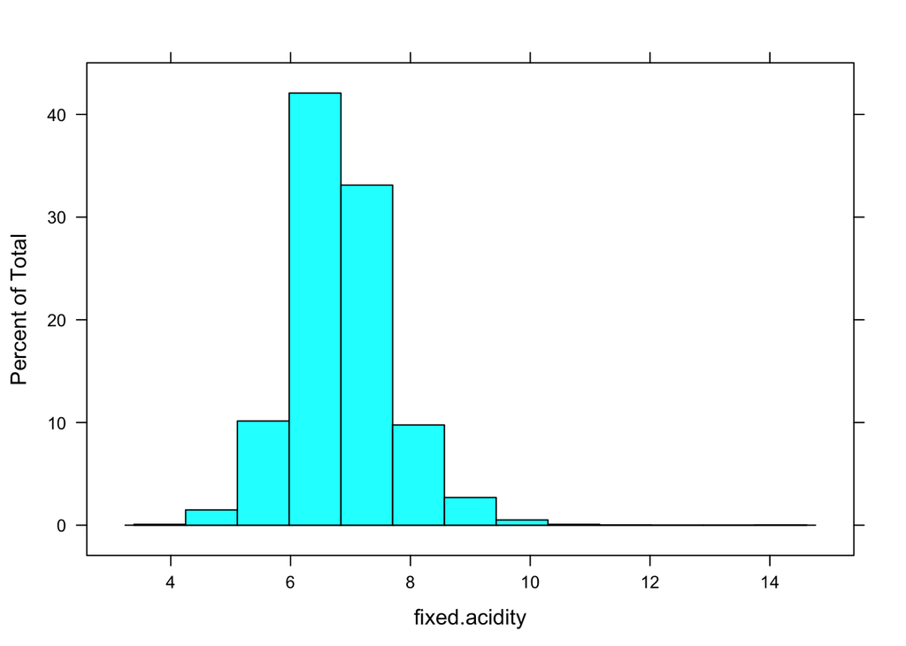

```r
#To get univariate graphs for all the variables
histogram(~fixed.acidity, data=White_wines)
```

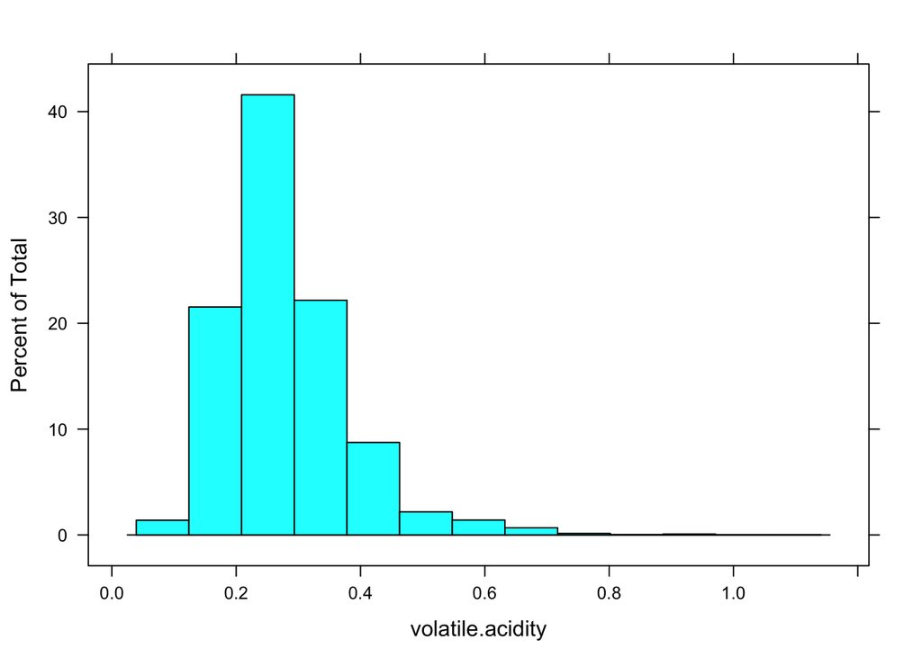

```r
histogram(~volatile.acidity, data=White_wines)
```

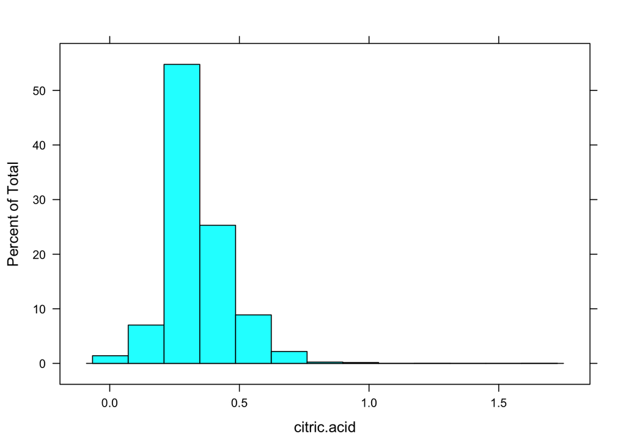

```r
histogram(~citric.acid, data=White_wines)
```

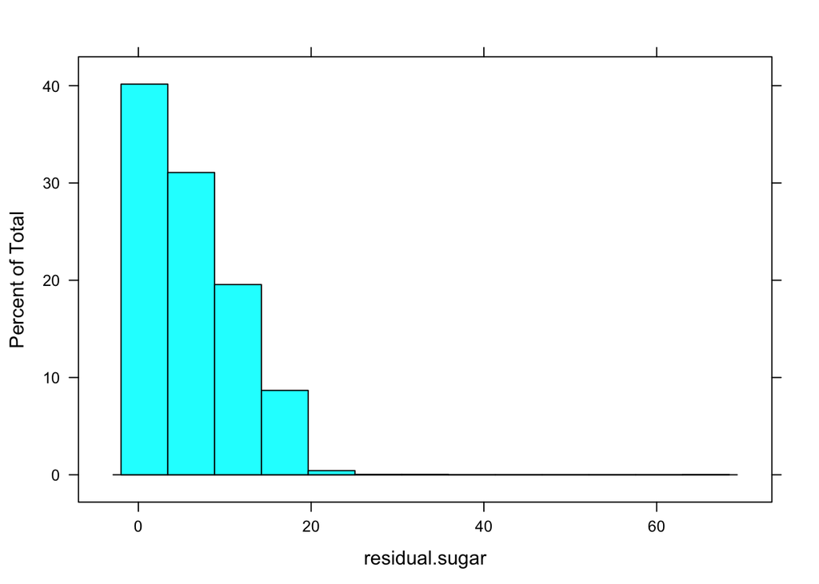

```r
histogram(~residual.sugar, data=White_wines)
```

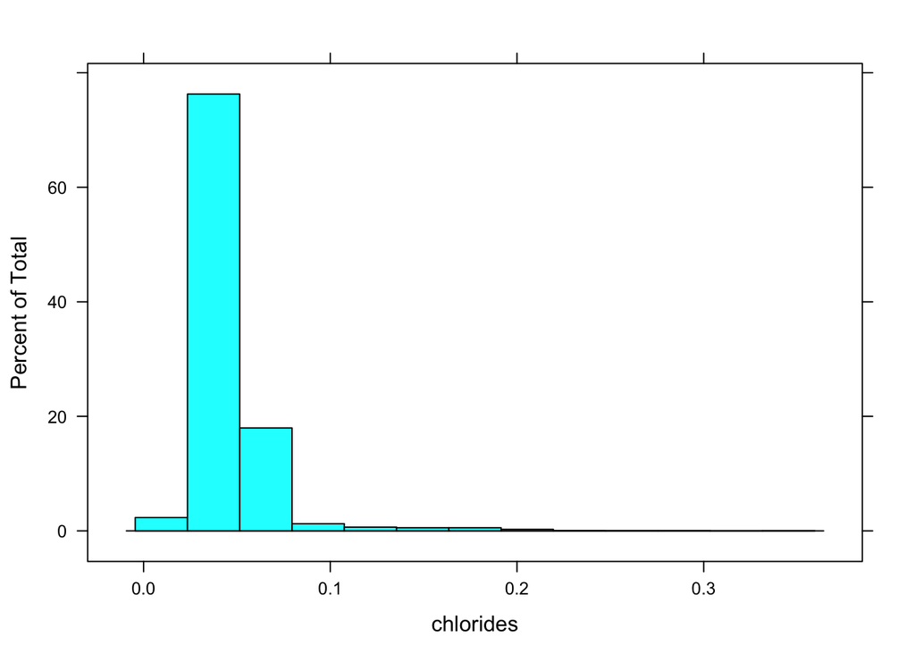

```r
histogram(~chlorides, data=White_wines)
```

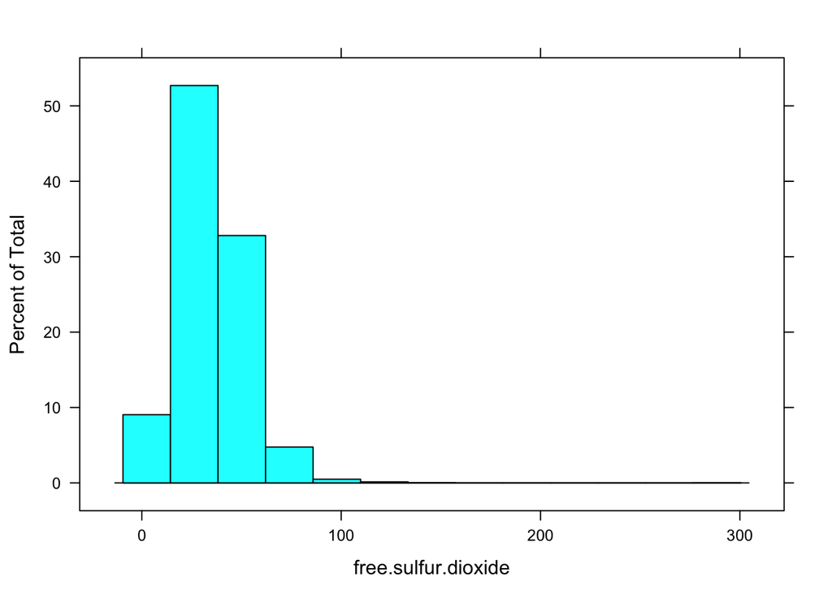

```r
histogram(~free.sulfur.dioxide, data=White_wines)
```

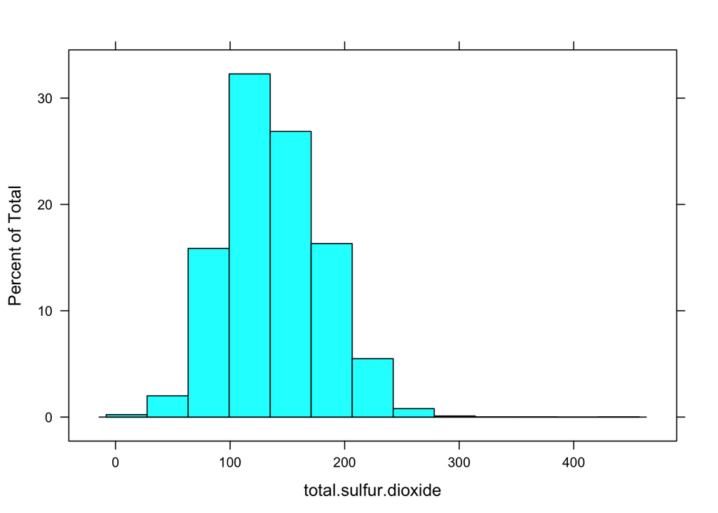

```r
histogram(~total.sulfur.dioxide, data=White_wines)
```

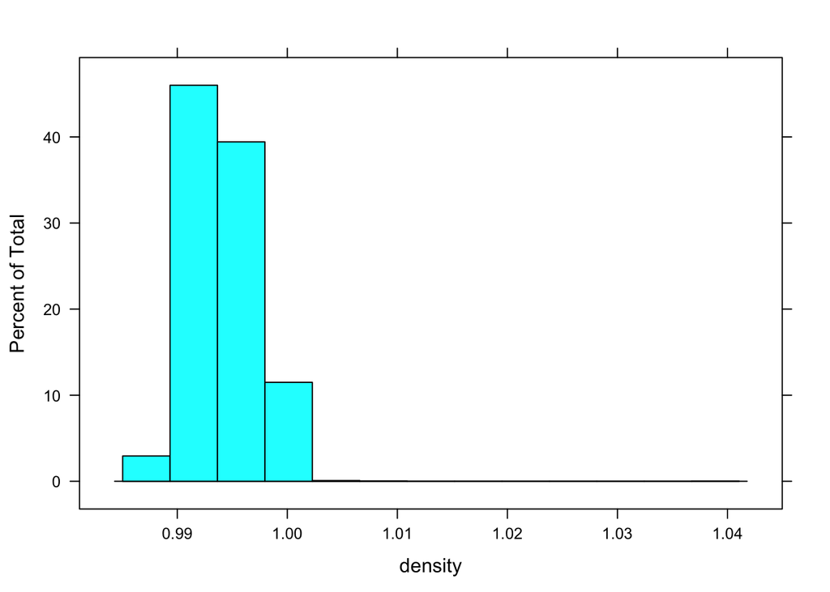

```r
histogram(~density, data=White_wines)
```

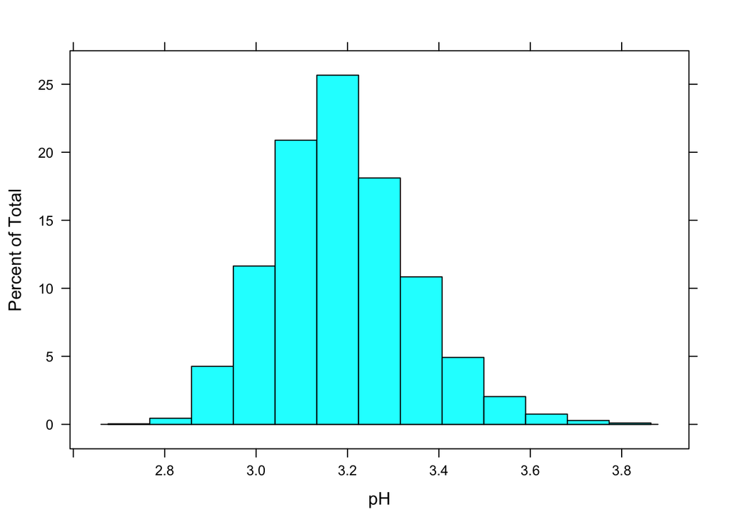

```r
histogram(~pH, data=White_wines)
```

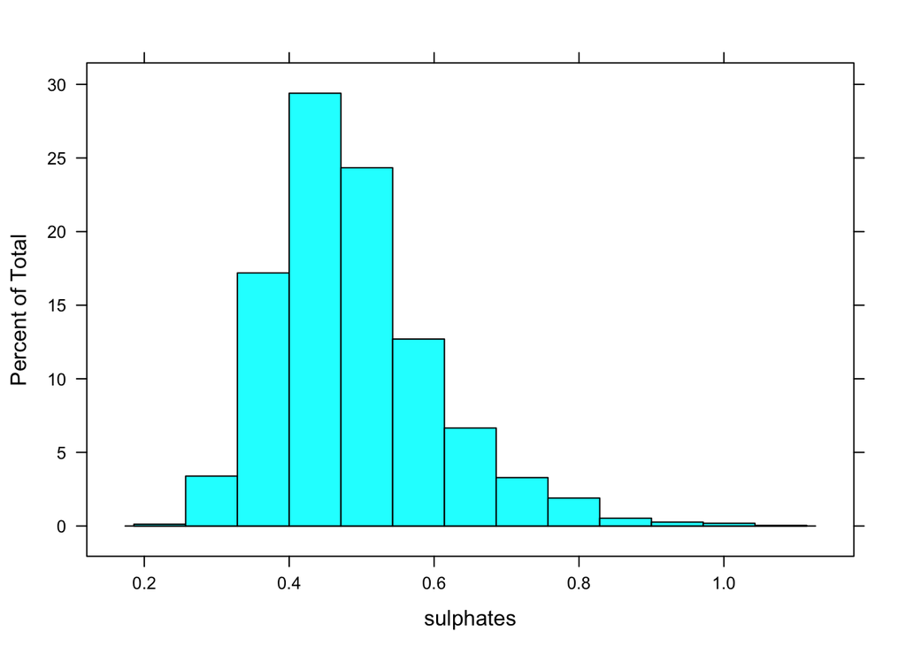

```r
histogram(~sulphates, data=White_wines)
```

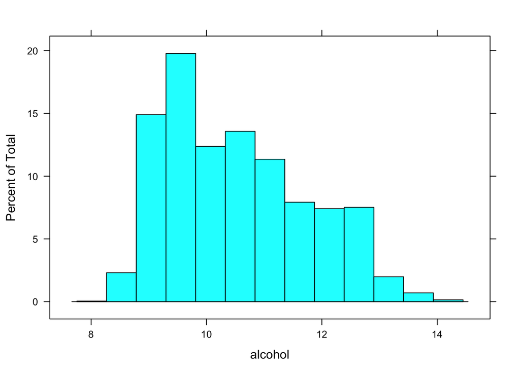

```r
histogram(~alcohol, data=White_wines)
```

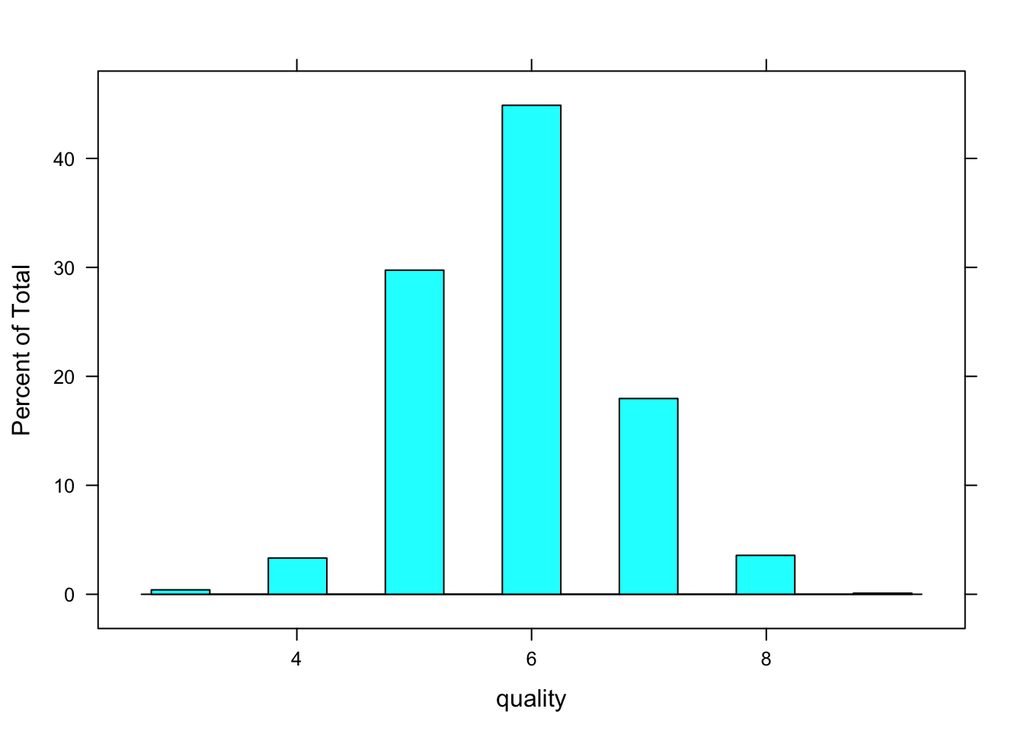

```r
histogram(~quality, data=White_wines)
```

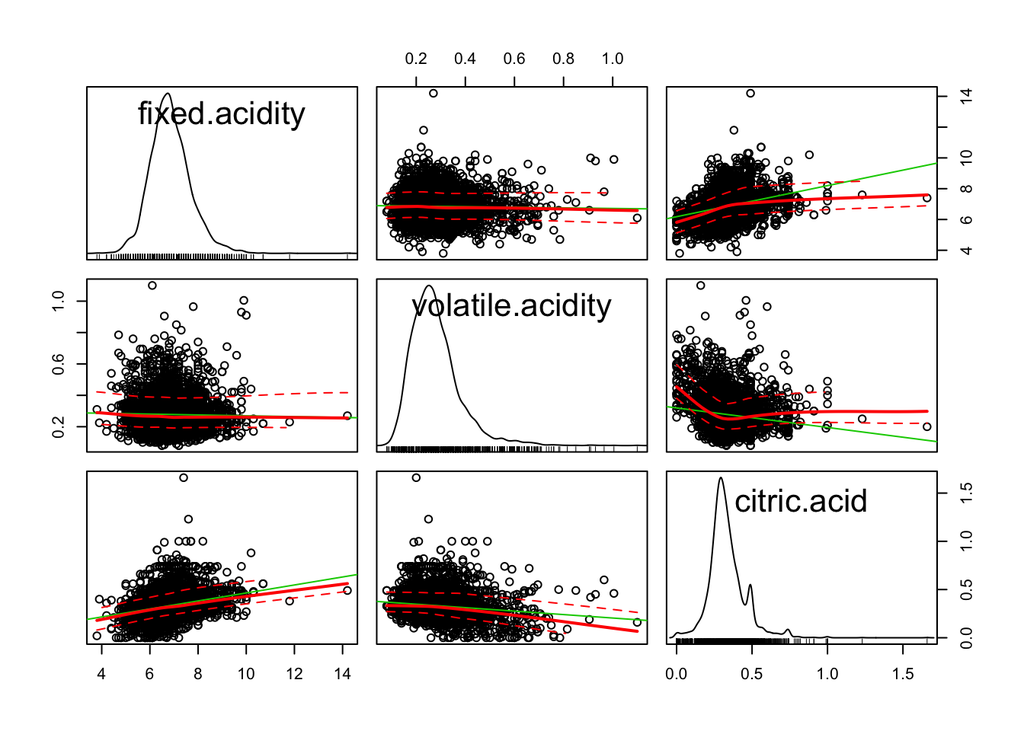

```r
#To get multivariate graphs
scatterplotMatrix(~fixed.acidity + volatile.acidity + citric.acid, data=White_wines)
```